# CS 372/472 & LRN_SCI 372/472

Using Turtles to Build Models

Prof. Connor Bain

connor.bain@northwestern.edu

April 9, 2026

## Logistical Stuff

**Exercise 2**

**Reminder**, exercise is due on SUNDAY at 11:59pm via Canvas.

- Please make sure to follow along in the textbook. There are lots more examples in there that might be more interesting to you than the ones we get to in class.
- As we start doing more and more programming, the [Beginners NetLogo Dictionary (BIND)](https://ccl.northwestern.edu/netlogo/bind/) will be more and more useful!

## Game of Life (Conway & Gardener, 1970s)

### SETUP

- Infinite checkerboard (2D) of patches where each patch is either alive (green) or dead (dark blue)

### GO

- Each cell looks at its Moore neighborhood (8)
  - If I have fewer than two live neighbors, I die.
  - If I have exactly two live neighbors, I stay unchanged.
  - If I have exactly three live neighbors, I become (or stay) alive.
  - If I have more than three live neighbors, I die.

## Game of Life in NetLogo (Us, 2026)

```
  ; patches update their status
  ask patches [
    if live-neighbors = 3 [ set pcolor green ]  ; comfortable neighborhood - live cells born
    if live-neighbors < 2 [ set pcolor blue ]   ; isolated patches die
    if live-neighbors > 3 [ set pcolor blue ]   ; overcrowded patches die
  ]
```

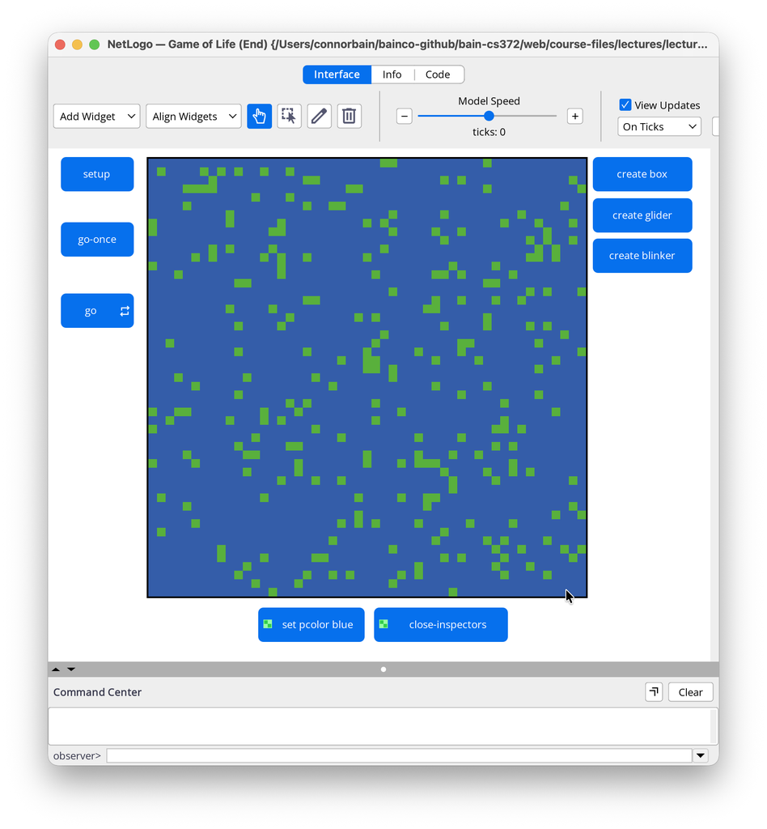

## Emergent Patterns

- **Still Lifes** (e.g., A 4 cell block-shape)
- **Oscillator patterns** repeat over time. (e.g., a blinker)
- **Spaceships**, some Life shapes can move across the Life world. (e.g., glider)

[video not shown]

## Universe as a Cellular Automata

- Konrad Zuse (1969) – Calculating Space
- Ed Fredkin (1990) – “We hypothesize that there will be found a single CA rule that models all of microscopic physics; and models it exactly.”
- Stephen Wolfram – Classified all 1D CA

# NetLogo Syntax Specifics

## Primitive Types

Two basic types of primitives:

- **Commands**: change things in the world (function with no return value)
- **Reporters**: give you information about stuff (function with a return value)

## Examples!

#### Commands

- `forward` (`fd`)
- `right` (`rt`)
- `create-turtles` (`crt`)
- `set`
- `ask`
- `show`

#### Reporters

- `heading`
- `color`
- `random`
- `one-of`
- `turtles`
- `length`

# Student Presentation

## Heroes and Cowards

- A game played at various Complex Systems conferences

### SETUP

- People spread out in a room
- Each person is assigned as a hero or a coward
- Each person picks one other person (in their head) to be their `friend` and one to be their `enemy`

### GO

- If you are a hero, move toward the midpoint between your `friend` and `enemy`
- If you are a coward, move toward the spot behind your `friend` relative to your `enemy`

## Movement Behaviors

### Heroic Movement

- Move toward the midpoint between your `friend` and `enemy`

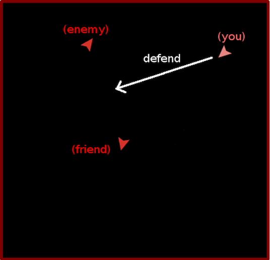

### Cowardly Movement

- Move toward the spot behind your `friend` relative to your `enemy`

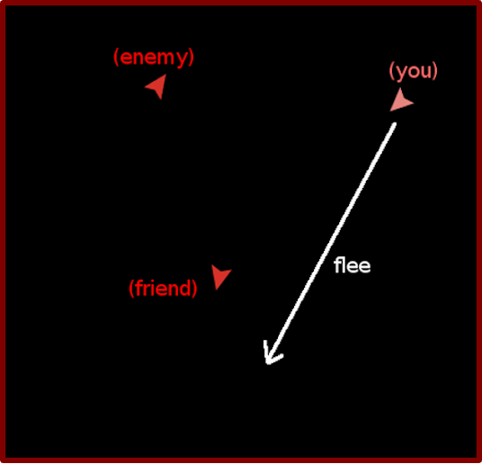

## More formalized Agent Rules

### SETUP

- Create `NUMBER` turtles at random locations
  - If `PERSONALITIES` is `“hero”`, color I’m blue
  - If `PERSONALITIES` is `“coward”`, color I’m yellow
  - If `PERSONALITIES` is `"mixed"`, flip a coin.
  - I pick one other turtle as a `friend`
  - I pick one other turtle as an `enemy`

### GO (at each tick)

- Each turtle asks itself:
  - If I’m blue, I act heroically
  - If I’m yellow, I’ll act cowardly

## Reminders!

**Exercise 2**

**Reminder**, exercise is due on SUNDAY at 11:59pm via Canvas.